# Exploratory Analysis

25 April, 2023

```r
lc <- read.csv("datasets/processed/lc.csv")
```

## First moment descriptive statistics

Plot Canada Lynx within BC

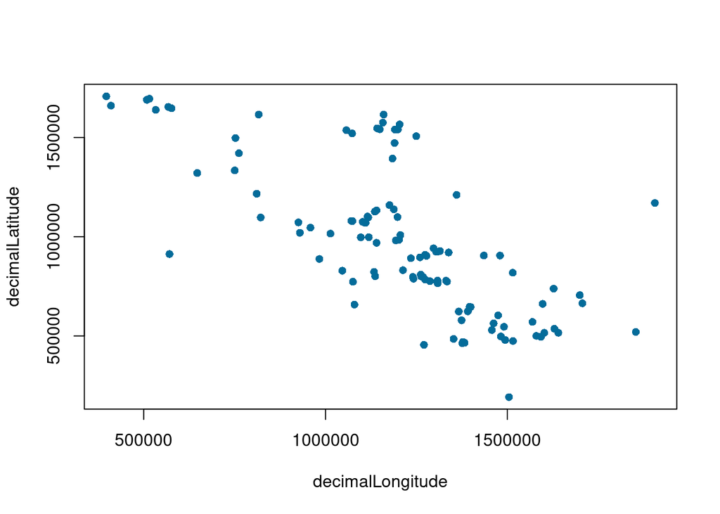

```r
plot(decimalLatitude ~ decimalLongitude,
     pch = 16,
     col = "#046C9A",
     data = lc)
```

Visualizing the observation window

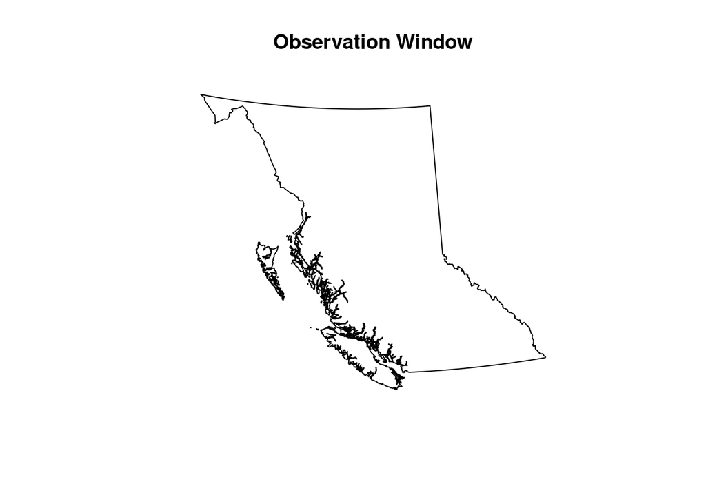

```r
library(spatstat)
library(sf)
load("datasets/raw/BC_Covariates.Rda")
# Create a SpatialPolygons object for the window
bc_window_sf <- st_as_sf(DATA$Window)
bc_window_owin <- as.owin(bc_window_sf)
# Visualize the window
plot(bc_window_owin, main = "Observation Window")
```

Plot observations in BC window

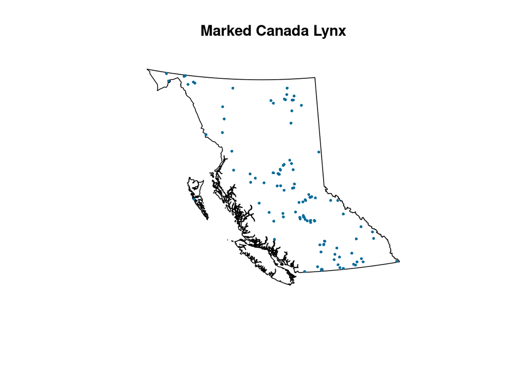

```r
# Convert to a ppp object
lc_ppp <- ppp(x = lc$decimalLongitude, # X coordinates
              y = lc$decimalLatitude, # Y coordinates
              window = bc_window_owin, # Observation window
              )

# Access the rejected points
# attr(lc_ppp, "rejects")

#  Remove rejected/out of window points
lc_ppp <- as.ppp(lc_ppp)

# Plot the ppp object
plot(lc_ppp,
     pch = 16,
     cex = 0.5,
     cols = "#046C9A",
     main = "Marked Canada Lynx")
```

```r
#Get units
unitname(lc_ppp)
```

```
## unit / units
```

```r
# summary(lc_ppp)
intensity(lc_ppp)
```

```
## [1] 1.856026e-10
```

### Intensity

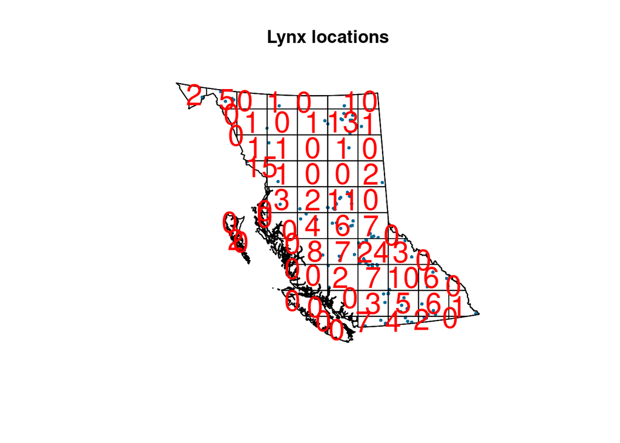

```r
#Split into a 3 by 3 quadrat and count points
Q <- quadratcount(lc_ppp,
                  nx = 10,
                  ny = 10)
#Plot the output
plot(lc_ppp,
     pch = 16,
     cex = 0.5,
     cols = "#046C9A",
     main = "Lynx locations")

plot(Q, cex = 2, col = "red", add = T)
```

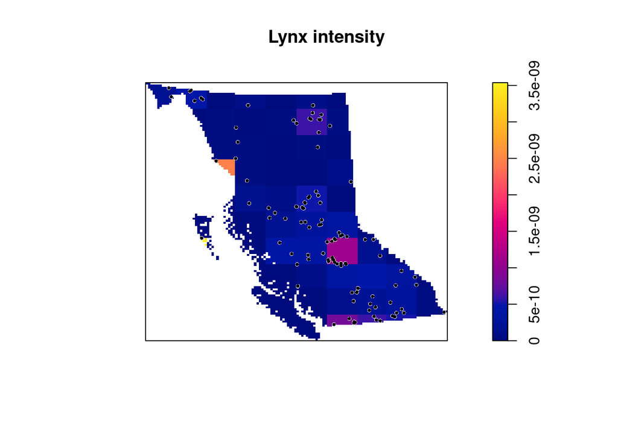

```r
#Plot the output Note the use of image = TRUE
plot(intensity(Q, image = T),
     main = "Lynx intensity")

plot(lc_ppp, pch = 16, cex = 0.6, cols = "white", add = T)

plot(lc_ppp, pch = 16, cex = 0.5, cols = "black", add = T)
```

From the above plot it can be seen that the assumption of homogeneity is not appropriate for this dataset as the lynx tend to be clustered in certain areas of the study site, whereas others have no lynx at all.

Quadrat test of homogeneity

```r
quadrat.test(Q)
```

```
##
##  Chi-squared test of CSR using quadrat counts
##
## data:
## X2 = 466.57, df = 63, p-value < 2.2e-16
## alternative hypothesis: two.sided
##
## Quadrats: 64 tiles (irregular windows)
```

The small p-value suggests that there is a significant deviation from homogeneity. So, the assumption of homogeneity is not met.

### Relationships with covariates

We are usually interested in determining whether the intensity depends on a covariate(s). One simple approach to check for a relationship between inhomogeneous $\lambda(u)$ and a spatial covariate $Z(u)$ is via quadrat counting.

```r
# Create 5 elevation classes with equal width
elev_classes <- cut(DATA$Elevation, breaks = 5, labels = c("low", "low-medium", "medium", "high-medium", "high"))
table(elev_classes[lc_ppp])
```

```
##
##         low  low-medium      medium high-medium        high
##          51         111          14           0           0
```

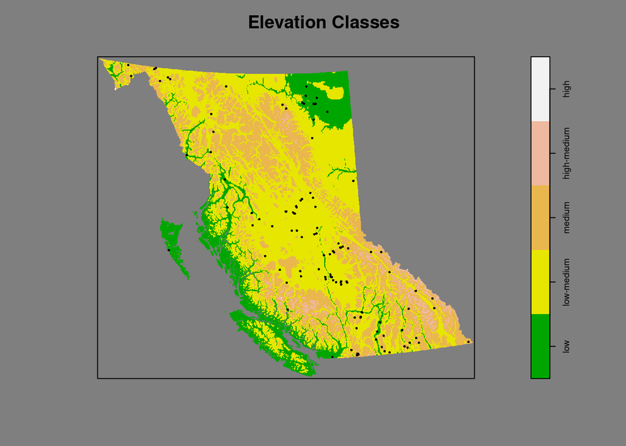

```r
library(viridis)
cols = terrain.colors(5)
# Plot the elevation class image and overlay the lynx locations
plot(elev_classes, col = cols, main = "Elevation Classes", par(bg="grey50", cex.main = 2, cex = 0.6))
points(lc_ppp, pch = 16, cex = 0.6, col = "black")
```

```r
# Create 5 forest classes with equal width
forest_classes <- cut(DATA$Forest, breaks = 5, labels = c("low", "low-medium", "medium", "high-medium", "high"))
table(forest_classes[lc_ppp])
```

```
##
##         low  low-medium      medium high-medium        high
##          61          34          21          18          42
```

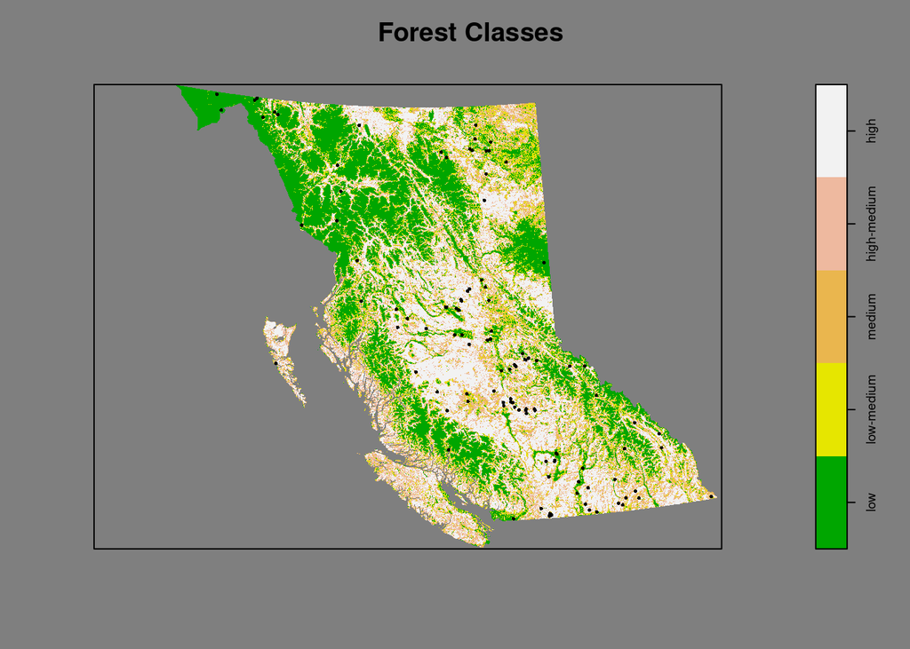

```r
# Plot the forest class image and overlay the lynx locations
plot(forest_classes, col = cols, main = "Forest Classes", par(bg="grey50", cex.main = 2, cex = 0.6))
points(lc_ppp, pch = 16, cex = 0.6, col = "black")
```

```r
# Create 5 human footprint index classes with equal width
hfi_classes <- cut(DATA$HFI, breaks = 5, labels = c("low", "low-medium", "medium", "high-medium", "high"))
table(hfi_classes[lc_ppp])
```

```
##
##         low  low-medium      medium high-medium        high
##          81          38           4          19          30
```

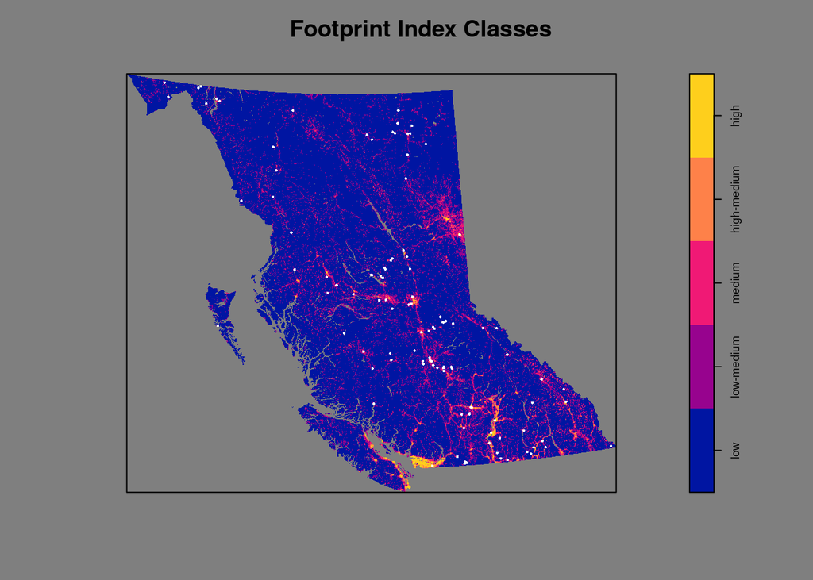

```r
# Plot the human footprint index class image and overlay the lynx locations
plot(hfi_classes, main = "Footprint Index Classes", par(bg="grey50", cex.main = 2, cex = 0.6))
points(lc_ppp, pch = 16, cex = 0.5, col = "white")
```

```r
# Create 5 dist water classes with equal width
dist_water_classes <- cut(DATA$Dist_Water, breaks = 5, labels = c("low", "low-medium", "medium", "high-medium", "high"))
table(dist_water_classes[lc_ppp])
```

```
##
##         low  low-medium      medium high-medium        high
##         167           7           2           0           0
```

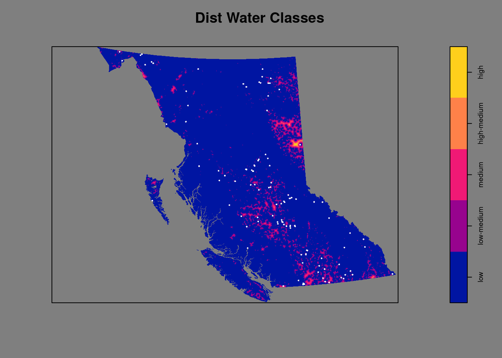

```r
# Plot the dist wanter class image and overlay the lynx locations
plot(dist_water_classes, main = "Dist Water Classes", par(bg="grey50", cex.main = 2, cex = 0.6))
points(lc_ppp, pch = 16, cex = 0.5, col = "white")
```

Based on a visual inspection, it appears that the heterogeneity observed in the data may be associated with a preference for certain elevations and distances from water.

More formally, in testing for relationships with covariates we are assuming that $λ$ is a function of $Z$, such that
$$\lambda(u)=\rho(Z(u))$$

A non-parametric estimate of $\rho$ can be obtained via kernel estimation, available via the rhohat() function.

```r
#Estimate Rho
rho <- rhohat(lc_ppp, DATA$Elevation)
```

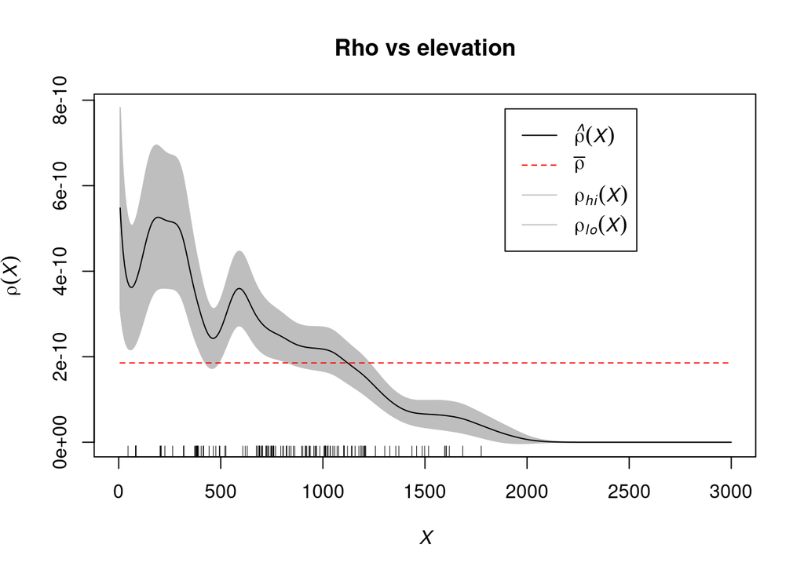

```r
plot(rho, xlim = c(0,3000), main = "Rho vs elevation")
```

As the rho values varying at different elevations without and also the rho values are not close to 0 from 0 to 2000 elevation. So, there’s a non-linear relationship between elevation and lynx intensity.

### Plot on BC Map

```r
library(raster)
dmap1 <- density.ppp(lc_ppp, sigma = bw.ppl(lc_ppp),edge=T)
r1 <- raster(dmap1)
```

```r
library(leaflet)
#make sure we have right CRS, which in this case is British National Grid

bc_crs <- "+proj=aea +lat_0=45 +lon_0=-126 +lat_1=50 +lat_2=58.5 +x_0=1000000 +y_0=0 +datum=NAD83 +units=m +no_defs"

crs(r1) <- sp::CRS(bc_crs)
```

```r
# create a colour palet
pal <- colorNumeric(c("#41B6C4", "red"), values(r1),
  na.color = "transparent")

#and then make map!
leaflet() %>%
  addTiles() %>%
  addRasterImage(r1, colors = pal, opacity = 0.8) %>%
  addLegend(pal = pal, values = values(r1),
    title = "Canada Lynx in BC")
```

[interactive chart not shown]

### Nearest neighbour distances

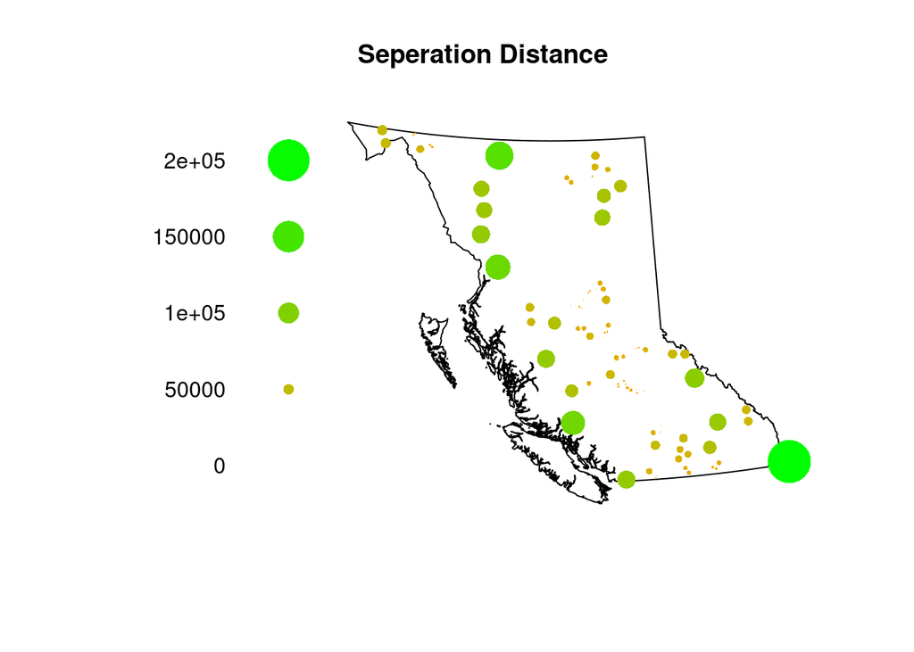

```r
col_pal <- colorRampPalette(c('orange', 'green'))
# Calculate nearest neighbor distances
nn_dist <- data.frame(nndist(lc_ppp))
# Add distance to nearest neighbor mark
marks(lc_ppp) <- nn_dist
# Plot point pattern with distance to nearest neighbor mark
plot(lc_ppp, main = "Seperation Distance",
     which.marks = NULL,
     cols = col_pal(nrow(nn_dist)), #The colours of the points
     pch = 16)
```

## Second Moment Descriptives

### K-Function

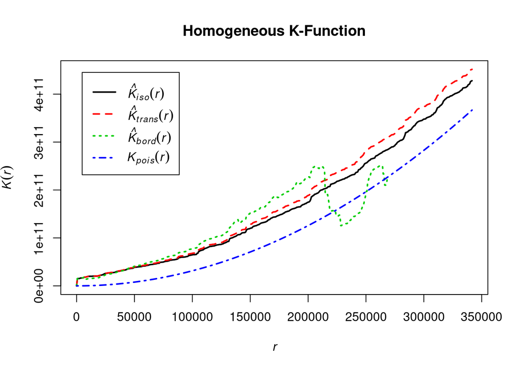

```r
# Estimate the k- function
k_lc <- Kest(lc_ppp)
# visualise the results
plot (k_lc, main = "Homogeneous K-Function", lwd = 2)
```

Here we can see that theoretical k-function $k_{pois}(r)$ deviates from other k-function corrections indicates clustering but these estimates assume homogeneity.

```r
# Bootstrapped CIs
# rank = 1 means the max and min
# values will be used for CI
E_lc <- envelope(lc_ppp , Kest , rank = 1, nsim = 19, fix.n = T)
```

```
## Generating 19 simulations of CSR with fixed number of points  ...
## 1, 2, 3, 4, 5, 6, 7, 8, 9, 10, 11, 12, 13, 14, 15, 16, 17, 18,  19.
##
## Done.
```

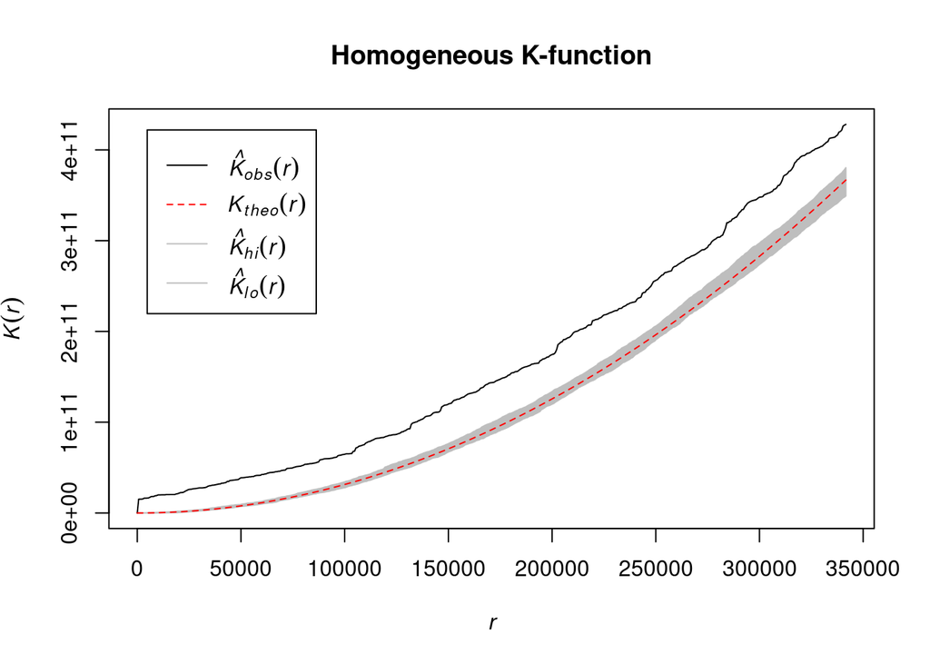

```r
# visualise the results
plot (E_lc , main = "Homogeneous K-function")
```

Now we have evidence that suggests significant clustering, but these estimates assume homogeneity.

Relaxing homogeneity assumption.

```r
#Estimate intensity
lambda_lc <- density(lc_ppp, bw.ppl)
Kinhom_lc <- Kinhom(lc_ppp, lambda_lc)
# Estimate a strictly positive density
lambda_lc_pos <- density(lc_ppp, sigma=bw.ppl, positive=TRUE)
# Simulation envelope (with points drawn from the estimated intensity)
E_lc_inhom <- envelope(lc_ppp,
                        Kinhom,
                        simulate = expression(rpoispp(lambda_lc_pos)),
                        correction="border",
                        rank = 1,
                        nsim = 19,
                        fix.n = TRUE)
```

```
## Generating 19 simulations by evaluating expression  ...
## 1, 2, 3, 4, 5, 6, 7, 8, 9, 10, 11, 12, 13, 14, 15, 16, 17, 18,  19.
##
## Done.
```

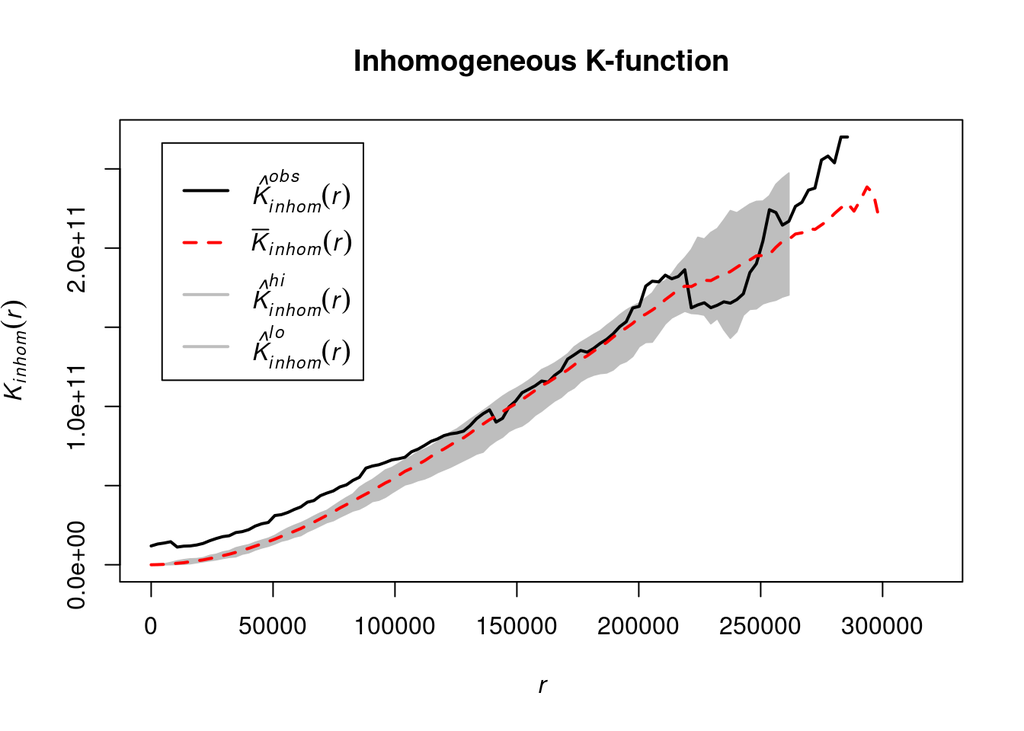

```r
# visualise the results
plot(E_lc_inhom, xlim = c(0,320000), main = "Inhomogeneous K-function", lwd = 2)
```